# Closing the gap in world health and economics - a data analysis project to convey the fact-based worldview

- Introduction
- Data Wrangling
- Exploratory Data Analysis
- Conclusions

## Introduction

> In this data analysis project, I intend to convey fact-based view about the world health and economics. Specifically, I have used data from [Gapminder.org](https://www.gapminder.org/) to attempt to answer the following two questions:

> **How does the income inequality across countries affect people's life expectancy and child mortality rate in their communities?**

> **Has the income inequality across countries worsened or gotten better in the last 60 years? What impact did this change have on life expectancy and child mortality rate?**

> To aid in my analysis, I downloaded the following four datasets in .csv format from Gapminder.org:
> 1. [GDP per capita](https://docs.google.com/spreadsheets/d/1gZZ28UiWCVue-tFHMEVOvSO58x7x-w20E23l1wZTR3E/edit#gid=176703676) - This dataset contains income per person (GDP per person adjusted for inflation and converted to international dollars using purchasing power parity), GDP total and GDP per capita growth % listed by country name for every year since 1800.
> 2. [Child mortality](https://docs.google.com/spreadsheets/d/1Av7eps_zEK73-AdbFYEmtTrwFKlfruBYXdrnXAOFVpM/edit#gid=176703676) - This dataset contains child mortality rate (death of children under five year of age per 1000 live birth) listed by country name for every year since 1800.
> 3. [Life expectancy](https://docs.google.com/spreadsheets/d/11mulzUH3_cueq-V9D5KIlo9oHE9YYZrUSeVyCin7_rM/edit#gid=176703676) - This dataset contains life expectancy rate (the average number of years a newborn child would live if the current mortality patterns were to remain the same) listed by country name for every year since 1800.
> 4. [Population](https://docs.google.com/spreadsheets/d/14_suWY8fCPEXV0MH7ZQMZ-KndzMVsSsA5HdR-7WqAC0/edit#gid=176703676) - This dataset contains total population listed by country name for every year since 1800.

> To answer the questions, I will be analyzing and comparing the relationship between income, life expectancy and child mortality for two different years: 1960 and 2020.

```python
# import the required packages
import pandas as pd
import numpy as np
from functools import reduce
import matplotlib.pyplot as plt
import seaborn as sns
%matplotlib inline

# set default style and color for the graphs
sns.set_style("ticks")
sns.set_palette("colorblind")
```

## Data Wrangling

> In this section, I am
> - loading the data
> - cleaning the data
> - preparing the data for analysis

### Loading the data

> Here, I am loading each of the four datasets into separate dataframe.

```python
# funtion to load the data into dataframe
def load_data(filename):
    """
    This function reads a .csv file and loads into a dataframe
    argument: .csv file name
    returns: dataframe
    """
    df = pd.read_csv(filename)
    return df
```

```python
# load all the files into dataframes using the load_data function
df_income = load_data('GM-GDP per capita - Dataset - v27 - data-for-countries-etc-by-year.csv')
df_child_mortality = load_data('GM-Child Mortality - Dataset - v11 - data-for-countries-etc-by-year.csv')
df_life_expectancy = load_data('GM-Life Expectancy- Dataset - v11 - data-for-countries-etc-by-year.csv')
df_population = load_data('GM-Population - Dataset - v6 - data-for-countries-etc-by-year.csv')
```

### Cleaning the data

> Here, I am renaming the column headers and dropping the columns that I don't require.

```python
# funtion to standarize the column headings
def standardize_columns(df):
    """
    This function
        1. drops unwanted columns: 'geo', 'GDP total', 'GDP per capita growth (%)'
        (Note: if the column name is not present in the dataframe, it will ignore)
        2. replaces any space in the column name with underscore
        3. makes column name to all lower cases
        4. renames column name "name" to "country" and "time" to "year"
    argument: dataframe
    returns: updated dataframe
    """
    df.drop(['geo', 'GDP total', 'GDP per capita growth (%)'], axis = 1, inplace = True, errors = 'ignore')
    df.rename(columns = lambda x: x.strip().lower().replace(" ", "_"), inplace = True)
    df.rename(columns = {"name": "country", "time": "year"}, inplace = True)
    return df
```

```python
# standardize the column headings  in all the dataframes using the standardize_columns function
df_income = standardize_columns(df_income)
df_child_mortality = standardize_columns(df_child_mortality)
df_life_expectancy = standardize_columns(df_life_expectancy)
df_population = standardize_columns(df_population)
```

### Preparing the data

> Here, I am
> - selecting only rows for year 1960 and 2020
> - merging all the four dataframes into a single dataframe
> - creating new columns for analysis

#### Selecting rows

> Here, I am selecting the rows where the year = '1960' or '2020'

```python
# function to select specific rows from a dataframe
def select_rows(df):
    """
    This function selects only the rows where 'year' is equal to 1960 or 2020
    argument: dataframe
    returns: dataframe with only specific rows
    """
    df = df.loc[df['year'].isin([1960, 2020])]
    return(df)
```

```python
# select only 1960 and 2020 records from each dataframe using the select_rows function
df_income = select_rows(df_income)
df_child_mortality = select_rows(df_child_mortality)
df_life_expectancy = select_rows(df_life_expectancy)
df_population = select_rows(df_population)
```

#### Merging dataframes

> Here, I am merging all the four dataframes into a single dataframe and checking to see whether I have all required data for further analysis.

```python
# create a list of dataframes
dfs = [df_income, df_child_mortality, df_life_expectancy, df_population]

# merge all the four dataframes into a single dataframe
df = reduce(lambda left, right: pd.merge(left, right, on=['country', 'year']), dfs)
```

```python
# view the merged dataframe
df.head()
```

|  | country | year | income_per_person | child_mortality | life_expectancy | population |
| --- | --- | --- | --- | --- | --- | --- |
| 0 | Afghanistan | 1960 | 1525 | 356.90 | 39.31 | 8996967 |
| 1 | Afghanistan | 2020 | 1918 | 58.08 | 64.41 | 38928341 |
| 2 | Albania | 1960 | 2660 | 187.50 | 62.24 | 1636091 |
| 3 | Albania | 2020 | 13265 | 8.52 | 78.58 | 2877800 |
| 4 | Algeria | 1960 | 6476 | 242.54 | 52.50 | 11057864 |

```python
# check for any null values
df.isnull().sum()
```

```
country              0
year                 0
income_per_person    0
child_mortality      0
life_expectancy      0
population           0
dtype: int64
```

```python
# check the datatype of each column
df.dtypes
```

```
country               object
year                   int64
income_per_person      int64
child_mortality      float64
life_expectancy      float64
population             int64
dtype: object
```

> There is no null value in the merged dataframe and it has only the columns I intend to use for analysis. The income_per_person is the annual income. Though it can be used for analysis, a better value will be dollars_per_day. Luckily, income_per_person is an integer and I can divide it by 365 to get the dollars_per_day.

> I also need a categorical variable for income. I will be creating one in the next section.

#### Creating new columns

> Here, I am creating two new variables/columns:
> - dollars_per_day --> a continuous variable created by dividing income_per_person by 365.
> - income_levels --> a categorical variable created by grouping dollars_per_day into 4 different buckets, namely less than 8 dollars per day, between 8 and 16 dollars per day, between 16 and 32 dollars per day and more than 32 dollars per day. I don't want to use the terms "poor" or "rich" to categorize countries/people, because those terms are subjective and majority of the people live somewhere in the middle. I have used the following categories to group the countries by their income level:
>   > - 1-Meagre - average daily income of less than 8 dollars
>   > - 2-Low - average daily income between 8 and 16 dollars
>   > - 3-Medium - average daily income between 16 and 32 dollars
>   > - 4-High - average daily income of more than 32 dollars

```python
# create a new column 'dollars_per_day'
df['dollars_per_day'] = df['income_per_person']/365
```

```python
# check the descriptive statistics for the new column 'dollars_per_day'
df.dollars_per_day.describe()
```

```
count    372.000000
mean      33.896524
std       45.511220
min        1.131507
25%        6.530822
50%       14.923288
75%       38.732192
max      303.071233
Name: dollars_per_day, dtype: float64
```

```python
# define the bin edges in order to categorise based on dollars_per_day
income_level_bin_edges = [1.13, 8.00, 16.00, 32.00, 303.08]

# define the name for each bin
income_level_bins = ['1-Meagre', '2-Low', '3-Medium', '4-High']

# create a new column 'income_levels' based on dollars_per_day
df['income_levels'] = pd.cut(df['dollars_per_day'], income_level_bin_edges, labels = income_level_bins)
```

```python
# view the new columns
df.head()
```

|  | country | year | income_per_person | child_mortality | life_expectancy | population | dollars_per_day | income_levels |
| --- | --- | --- | --- | --- | --- | --- | --- | --- |
| 0 | Afghanistan | 1960 | 1525 | 356.90 | 39.31 | 8996967 | 4.178082 | 1-Meagre |
| 1 | Afghanistan | 2020 | 1918 | 58.08 | 64.41 | 38928341 | 5.254795 | 1-Meagre |
| 2 | Albania | 1960 | 2660 | 187.50 | 62.24 | 1636091 | 7.287671 | 1-Meagre |
| 3 | Albania | 2020 | 13265 | 8.52 | 78.58 | 2877800 | 36.342466 | 4-High |
| 4 | Algeria | 1960 | 6476 | 242.54 | 52.50 | 11057864 | 17.742466 | 3-Medium |

> Perfect! Now I have all the details to start the EDA.

## Exploratory Data Analysis

> First, let's explore how 1960 looked in terms of income, child mortality and life expectancy.

### World view in 1960

> Let's start by creating descriptive statistics and distribution for dollars per day.

```python
# check the descriptive statistics for the column 'dollars_per_day' for 1960
df.query('year == 1960').dollars_per_day.describe()
```

```
count    186.000000
mean      15.950214
std       22.249084
min        1.131507
25%        4.642466
50%        9.471233
75%       17.663699
max      196.945205
Name: dollars_per_day, dtype: float64
```

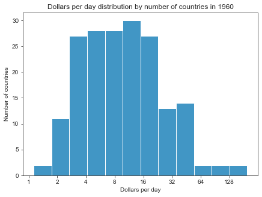

```python
# Plot an histogram showing distribution of dollars_per_day by number of countries in 1960

f, axes = plt.subplots(figsize = (7, 5))

# set the x-axis to log scale
axes = plt.gca()
axes.set_xscale('log', base = 2)
plt.xticks([2**i for i in range(8)],[2**i for i in range(8)])

# set the title and the labels
props = {
    'title': 'Dollars per day distribution by number of countries in 1960',
    'xlabel': 'Dollars per day',
    'ylabel': 'Number of countries'
}
axes.set(**props)

# plot the graph
sns.histplot(
    data = df.query('year == 1960'),
    x = "dollars_per_day"
);
```

> From the above stats and the graph, it is very clear that majority of the countries (nearly 70%) had a daily average income of 16 dollars or less in 1960.

> Next, let's look at the descriptive statistics and distribution for life expectancy.

```python
# check the descriptive statistics for the column 'life_expectancy' for 1960
df.query('year == 1960').life_expectancy.describe()
```

```
count    186.000000
mean      55.524086
std       10.878644
min       31.580000
25%       46.027500
50%       56.180000
75%       64.680000
max       74.030000
Name: life_expectancy, dtype: float64
```

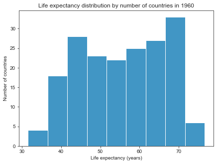

```python
# Plot an histogram showing distribution of life_expectancy by number of countries in 1960

f, axes = plt.subplots(figsize = (7, 5))

# set the title and the labels
props = {
    'title': 'Life expectancy distribution by number of countries in 1960',
    'xlabel': 'Life expectancy (years)',
    'ylabel': 'Number of countries'
}
axes.set(**props)

# plot the graph
sns.histplot(
    data = df.query('year == 1960'),
    x = "life_expectancy",
    binwidth = 5
);
```

> In 1960, life expectancy ranged from 31 to 74 years. The above graph shows bimodal distribution for life expectancy - one peak at around 45 years and another one at around 70 years. The bimodal distribution of life expectancy may be analogous to variation in income levels. Before we investigate the relationship, let's look into the descriptive statistics and distribution for child mortality.

```python
# check the descriptive statistics for the column 'child_mortality' for 1960
df.query('year == 1960').child_mortality.describe()
```

```
count    186.000000
mean     167.174731
std      105.001513
min       19.550000
25%       77.560000
50%      150.615000
75%      252.267500
max      423.410000
Name: child_mortality, dtype: float64
```

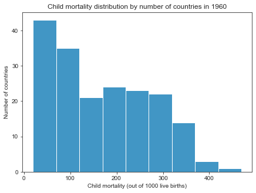

```python
# Plot an histogram showing distribution of child_mortality by number of countries in 1960

f, axes = plt.subplots(figsize = (7, 5))

# set the title and the labels
props = {
    'title': 'Child mortality distribution by number of countries in 1960',
    'xlabel': 'Child mortality (out of 1000 live births)',
    'ylabel': 'Number of countries'
}
axes.set(**props)

# plot the graph
sns.histplot(
    data = df.query('year == 1960'),
    x = "child_mortality",
    binwidth = 50
);
```

> In 1960, there was a wide range of child mortality among countries ranging from 20 to 425, with median at around 150. Similar to life expectancy, the variation in child mortality may be analogous to variation in income levels.

> How did the dollars per day or income levels impact life expectancy and child mortality? Let's find out next.

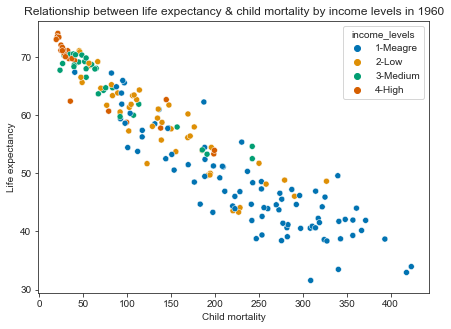

```python
# Plot a scatterplot showing the realtionship between life_expectancy & child_mortality for various income_levels in 1960

f, axes = plt.subplots(figsize = (7, 5))

# set the title and the labels
props = {
    'title': 'Relationship between life expectancy & child mortality by income levels in 1960',
    'xlabel': 'Child mortality',
    'ylabel': 'Life expectancy'
}
axes.set(**props)

# plot the graph
sns.scatterplot(
    data = df.query('year == 1960'),
    x = "child_mortality",
    y = "life_expectancy",
    hue = "income_levels"
);
```

> From the above graph, it is very apparent that the life expectancy and the child mortality were very much impacted by the countries' income levels. Countries with meagre income level were characterized by high child mortality and low life expectancy, while the countries with high income level had just the opposite.

> A reminder about income levels:
> - 1-Meagre --> countries with daily average income of 8.00 dollars or less
> - 2-Low --> countries with daily average income between 8.00 and 16.00 dollars
> - 3-Medium --> countries with daily average income between 16.00 and 32.00 dollars
> - 4-High --> countries with daily average income of 32.00 dollars or more

> Let's plot some graphs by income levels and see how the variation in life expectancy and child mortality are crystal clear among the various income levels.

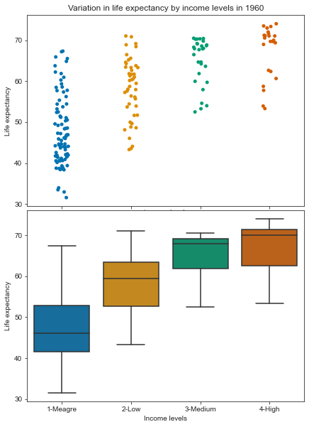

```python
# Plot a stripplot and a boxplot to compare the life_expectancy in 1960 by income_levels

f, axes = plt.subplots(2, 1, figsize = (7, 10), sharex = True)

# adjust the space between the plots
plt.subplots_adjust(hspace = .02)

# plot the 1st graph, the stripplot
sns.stripplot(
    ax = axes[0],
    data = df.query('year == 1960'),
    x = "income_levels",
    y = "life_expectancy"
)

# set the title and labels
axes[0].set_title("Variation in life expectancy by income levels in 1960")
axes[0].set_ylabel("Life expectancy")

# plot the 2nd graph, the boxplot
sns.boxplot(
    ax = axes[1],
    data = df.query('year == 1960'),
    x = "income_levels",
    y = "life_expectancy"
)

# set the labels
axes[1].set_xlabel("Income levels")
axes[1].set_ylabel("Life expectancy");
```

> In 1960, people in high income level countries were expected to live on an average 25 years longer than the people in meagre income level countries and there is an increase in median life expectancy as we move from meagre income level countries to high income level countries.

> Next, let's find out what was the impact on child mortality.

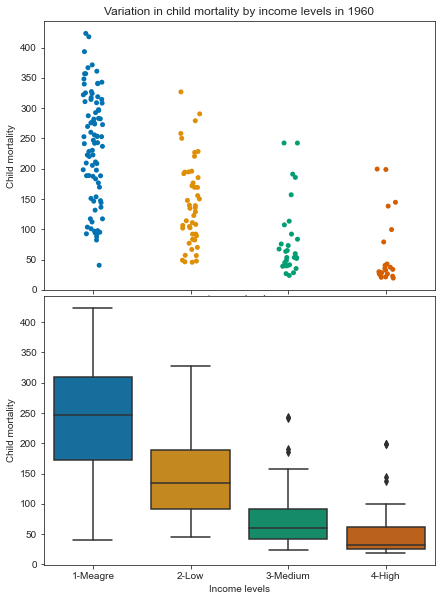

```python
# Plot a stripplot and a boxplot to compare the child_mortality in 1960 by income_levels

f, axes = plt.subplots(2, 1, figsize = (7, 10), sharex = True)

# adjust the space between the plots
plt.subplots_adjust(hspace = .02)

# plot the 1st graph, the stripplot
sns.stripplot(
    ax = axes[0],
    data = df.query('year == 1960'),
    x = "income_levels",
    y = "child_mortality"
)

# set the title and labels
axes[0].set_title("Variation in child mortality by income levels in 1960")
axes[0].set_ylabel("Child mortality")

# plot the 2nd graph, the boxplot
sns.boxplot(
    ax = axes[1],
    data = df.query('year == 1960'),
    x = "income_levels",
    y = "child_mortality"
)

# set the labels
axes[1].set_xlabel("Income levels")
axes[1].set_ylabel("Child mortality");
```

### World view in 2020 and how it compares with that in 1960

> Again, let's use some descriptive statistics and graphs to find out whether the world view changed in 2020. If it did, how did it compare with that in 1960.

> Let's start by comparing dollars per day and number of countries by income levels between 1960 and 2020.

```python
# check the descriptive statistics for the column 'dollars_per_day' for 2020
df.query('year == 2020').dollars_per_day.describe()
```

```
count    186.000000
mean      51.842834
std       54.873442
min        1.843836
25%       11.552055
50%       32.732877
75%       75.699315
max      303.071233
Name: dollars_per_day, dtype: float64
```

> From 1960 to 2020, the mean dollars per day jumped from 15.95 to 51.84 and the median from 9.47 to 32.73. Let's see the change with the help of a graph.

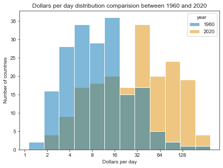

```python
# Plot an histogram showing how the distribution of dollars_per_day changed between 1960 and 2020

f, axes = plt.subplots(figsize = (7, 5))

# set the x-axis to log scale
axes = plt.gca()
axes.set_xscale('log', base=2)
plt.xticks([2**i for i in range(8)],[2**i for i in range(8)])

# set the title and the labels
props = {
    'title': 'Dollars per day distribution comparision between 1960 and 2020',
    'xlabel': 'Dollars per day',
    'ylabel': 'Number of countries'
}
axes.set(**props)

# plot the graph
sns.histplot(
    data = df,
    x = "dollars_per_day",
    hue = "year",
    multiple = "layer",
    palette = "colorblind"
);
```

> From the graph it is clear that the income level of countries improved between 1960 and 2020. Let's find out how many countries jumped income levels.

```python
# count the number of countries by income_levels in 1960 and 2020
country_counts = pd.crosstab(df['income_levels'], df['year'])
country_counts
```

| year income_levels | 1960 | 2020 |
| --- | --- | --- |
| 1-Meagre | 87 | 32 |
| 2-Low | 47 | 29 |
| 3-Medium | 29 | 31 |
| 4-High | 23 | 94 |

> In 1960, nearly 50% (87 out of 186) of the countries were in the meagre income level with their people earning daily average income of 8 dollars or less. In 2020, that number dropped to 32 countries or 17%. On the contrary, in 1960, only 23 countries (or 12%) were in the high income level. In 2020, that number increased to 94 countries (or 50%).

> From the numbers, it is clear that many countries moved up the income levels between 1960 and 2020, closing the gap in income inequalities. Let's confirm this by considering how the population varied by income levels between 1960 and 2020. In order to do the comparison, let's first calculate total population and population percentage by income levels for each year: 1960 and 2020.

```python
# sum the population by year and then by income_levels
population_total = df.groupby(['year', 'income_levels']).sum()['population']

# find the proportion of population by income_levels for each year (1960 and 2020)
population_percent = population_total.groupby(level=0).apply(lambda x: 100 * x / float(x.sum()))

# convert the total/percent series into dataframe and reset the index for using to plot graphs
population_total = population_total.to_frame().reset_index()
population_percent = population_percent.to_frame().reset_index()
print(population_total)
print(population_percent)
```

```
   year income_levels  population
0  1960      1-Meagre  1787474011
1  1960         2-Low   337034731
2  1960      3-Medium   459272170
3  1960        4-High   446648891
4  2020      1-Meagre   693054508
5  2020         2-Low  1027109622
6  2020      3-Medium  2260952602
7  2020        4-High  3804914639
   year income_levels  population
0  1960      1-Meagre   58.984175
1  1960         2-Low   11.121681
2  1960      3-Medium   15.155348
3  1960        4-High   14.738797
4  2020      1-Meagre    8.901255
5  2020         2-Low   13.191696
6  2020      3-Medium   29.038576
7  2020        4-High   48.868473
```

> Now that we have the numbers for total population and population percentage by income levels, let's plot the graphs.

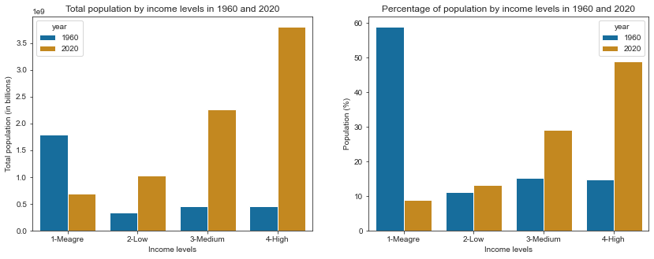

```python
# Plot barcharts showing how the total/percent population changed by income_levels between 1960 and 2020

f, axes = plt.subplots(1, 2, figsize = (14, 5))

# plot the total barchart
sns.barplot(
    ax = axes[0],
    data = population_total,
    x = "income_levels",
    y = "population",
    hue = "year"
)

# set the title and labels
axes[0].set_title("Total population by income levels in 1960 and 2020")
axes[0].set_xlabel("Income levels")
axes[0].set_ylabel("Total population (in billions)")

# plot the percent barchart
sns.barplot(
    ax = axes[1],
    data = population_percent,
    x = "income_levels",
    y = "population",
    hue = "year"
)

# set the title and labels
axes[1].set_title("Percentage of population by income levels in 1960 and 2020")
axes[1].set_xlabel("Income levels")
axes[1].set_ylabel("Population (%)");
```

> The population graphs re-confirm the conclusion about closing the gap in income inequalities. While majority of the world population (about 59%) lived with a meagre daily income of 8 dollars or less in 1960, a majority of the population (nearly 50%) live with a daily income of 32 dollars or more now in 2020.

> Next, let's see how the life expectancy and child mortality changed in 2020 using some descriptive statistics and distribution graphs.

```python
# check the descriptive statistics for the column 'life_expectancy' for 2020
df.query('year == 2020').life_expectancy.describe()
```

```
count    186.000000
mean      73.490376
std        6.845959
min       53.300000
25%       68.620000
50%       74.535000
75%       78.637500
max       85.290000
Name: life_expectancy, dtype: float64
```

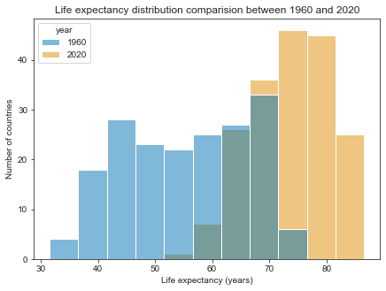

```python
# Plot an histogram showing how the distribution of life_expectancy changed between 1960 and 2020

f, axes = plt.subplots(figsize = (7, 5))

# set the title and the labels
props = {
    'title': 'Life expectancy distribution comparision between 1960 and 2020',
    'xlabel': 'Life expectancy (years)',
    'ylabel': 'Number of countries'
}
axes.set(**props)

# plot the graph
sns.histplot(
    data = df,
    x = "life_expectancy",
    binwidth = 5,
    hue = "year",
    multiple = "layer",
    palette = "colorblind"
);
```

```python
# check the descriptive statistics for the column 'child_mortality' for 2020
df.query('year == 2020').child_mortality.describe()
```

```
count    186.000000
mean      26.781989
std       27.317627
min        1.580000
25%        6.550000
50%       15.225000
75%       42.607500
max      116.520000
Name: child_mortality, dtype: float64
```

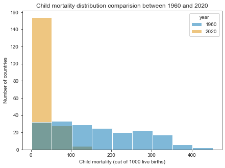

```python
# Plot an histogram showing how the distribution of child_mortality changed between 1960 and 2020

f, axes = plt.subplots(figsize = (7, 5))

# set the title and the labels
props = {
    'title': 'Child mortality distribution comparision between 1960 and 2020',
    'xlabel': 'Child mortality (out of 1000 live births)',
    'ylabel': 'Number of countries'
}
axes.set(**props)

# plot the graph
sns.histplot(
    data = df,
    x = "child_mortality",
    binwidth = 50,
    hue = "year",
    multiple = "layer",
    palette = "colorblind"
);
```

> The child mortality reduced substantially between 1960 to 2020. For majority of the countries, child mortality rate fell below 100 in 2020.

> Now, let's focus on how the change in income levels impacted life expectancy and child mortality in 2020.

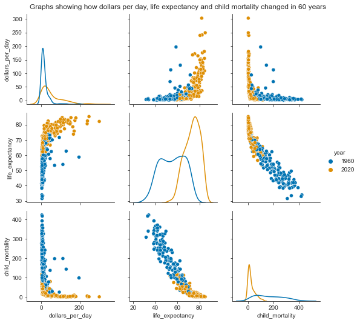

```python
# Plot a graph grid showing how the dollars_per_day, life_expectancy and child_mortality changed between 1960 and 2020

g = sns.PairGrid(
    data = df,
    vars = ["dollars_per_day", "life_expectancy", "child_mortality"],
    hue = "year",
    palette = "colorblind"
)
g.map_offdiag(sns.scatterplot)
g.map_diag(sns.kdeplot)
g.add_legend()
g.fig.subplots_adjust(top=0.95)
g.fig.suptitle("Graphs showing how dollars per day, life expectancy and child mortality changed in 60 years");
```

> We have already seen that dollars per day or income levels increased in 2020 when compared to 1960. The above graph shows that both life expectancy and child mortality improved in 2020 when compared to the 1960 rates. In other words, life expectancy went up and child mortality went down in 60 years.

> Let's explore this further and see how the changes show up across various income levels.

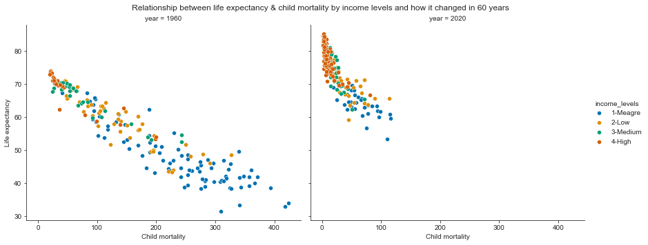

```python
# Plot a graph showing the realtionship between life_expectancy & child_mortality for various income_levels in 1960 & 2020

g = sns.FacetGrid(
    data = df,
    col = "year",
    hue = "income_levels",
    height = 5,
    aspect = 1.2
)
g.map(sns.scatterplot, "child_mortality", "life_expectancy")
g.add_legend()
g.set_axis_labels("Child mortality", "Life expectancy")
g.fig.subplots_adjust(top=0.9)
g.fig.suptitle("Relationship between life expectancy & child mortality by income levels and how it changed in 60 years");
```

> The above graph says it all - how the gap with respect to life expectancy and child mortality is getting closer among countries with various income levels . In 1960, as we have seen earlier, the variation among countries was huge. In 2020, even though there is some variation among countries with various income levels, it is apparent that all countries are moving towards higher life expectancy and lower child mortality rate.

> Let's explore life expectancy and child mortality separately and see how the gap is getting closer among various income levels.

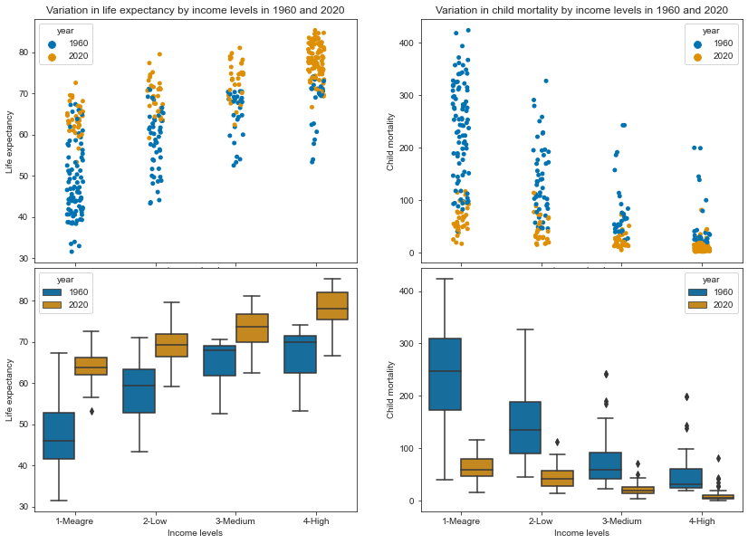

```python
# Plot graphs to compare the life_expectancy and child_mortality separately by income_levels and show how they changed in 60 yrs

f, axes = plt.subplots(2, 2, figsize = (14, 10), sharex = True)

# adjust the space between the plots
plt.subplots_adjust(hspace = .02)

# plot the stripplot for life expectancy
sns.stripplot(
    ax = axes[0,0],
    data = df,
    x = "income_levels",
    y = "life_expectancy",
    hue = "year"
)

# set the title and labels
axes[0,0].set_title("Variation in life expectancy by income levels in 1960 and 2020")
axes[0,0].set_ylabel("Life expectancy")

# plot the barplot for life expectancy
sns.boxplot(
    ax = axes[1,0],
    data = df,
    x = "income_levels",
    y = "life_expectancy",
    hue = "year"
)

# set the labels
axes[1,0].set_xlabel("Income levels")
axes[1,0].set_ylabel("Life expectancy");

# plot the stripplot for child mortality
sns.stripplot(
    ax = axes[0,1],
    data = df,
    x = "income_levels",
    y = "child_mortality",
    hue = "year"
)

# set the title and labels
axes[0,1].set_title("Variation in child mortality by income levels in 1960 and 2020")
axes[0,1].set_ylabel("Child mortality")

# plot the barplot for child mortality
sns.boxplot(
    ax = axes[1,1],
    data = df,
    x = "income_levels",
    y = "child_mortality",
    hue = "year"
)

# set the labels
axes[1,1].set_xlabel("Income levels")
axes[1,1].set_ylabel("Child mortality");
```

> **Child mortality** - between 1960 and 2020, the child mortality rate reduced considerably across all income levels. The rate of reduction is higher in the lower income level countries, bringing them closer to the child mortality rate in the higher income level countries.

## Conclusions

> In 1960, the variations in life expectancy and child mortality among countries in various income levels were very prominent. Countries with higher income level were characterized by higher life expectancy and lower child mortality. As we move down the income levels, life expectancy decreased and child mortality increased.

> The reduction in the income inequality among countries is having a positive effect on life expectancy and child mortality. As the income level of the countries increases, the variations in life expectancy and child mortality among countries in various income levels are reducing at a faster rate. Even though there are still some variations among countries, those variations are not as prominent as they were in 1960. If this trend continues, closing the gap in income, life expectancy, child mortality or any other indicators among countries is not far away.

> **Limitation:** The data provided for income, life expectancy and child mortality are the averages for each country. Within each country, the rates vary widely. The relationship discussed here between income and life expectancy and child mortality holds good only for the averages at the country level. It must be noted that states/provinces from the same country can be quite different and that states/provinces with the same income can have different life expectancy or child mortality rate.